# Estabilidad residencial

Lo que el análisis de supervivencia revela sobre Vivienda Primero en Chile  
VI Conferencia sobre Situación de Calle en América Latina · CISCAL · Montevideo, 16–19 de noviembre de 2026

Felipe Estay*, PhD

UC Chile, CISCAL

Ignacio Eissmann, PhD

Universidad Andrés Bello, CISCAL

* Declaración de intereses. El autor dirige Corporación Moviliza, ejecutor de Vivienda Primero.

# El problema

Por qué la retención decide, y cómo se mide en Chile

## La retención decide, y en Chile decide plata y ejecutores

- Housing First promete antes que nada que la persona **conserve su vivienda**. La retención es su resultado primario y el proxy de estabilidad, inclusión y bienestar (Aubry et al., 2020).
- En Chile gobierna tres instrumentos. El **indicador de propósito** certifica el programa ante Hacienda (DIPRES) y dos variaciones de la **fórmula de los concursos** asigna los convenios (MDSF).
- Los cupos son fijos y los convenios se disputan. Cuanto más decide un indicador, más presiona lo que mide (Campbell, 1979).

Si la retención decide, la forma de medirla decide.

## Seis formas de medir la retención, tres decisiones

|  | Cuándo se mira | Pérdida | Invariante |
| --- | --- | --- | --- |
| **M1** Puntual de cohorte · Pathways, HF Europe, Reino Unido | A $h$ meses del ingreso | No estar alojado en $t_i+h$ | Sí |
| **M2** Ponderada por tiempo · ensayos aleatorizados | Todo $[t_i,\,t_i+H]$ | Días fuera de vivienda | Sí |
| **M3** HUD 7b.2 · Estados Unidos | Cierre del período | $V, F, R$ | Parcial |
| **M4** Tasa ministerial · MDSF | Fecha de corte $C$ | $V, F, X, R$ | **No** |
| **M5** Concursos · MDSF | Fecha de corte $C$ | $V, F, R$ | **No** |
| **M6** Indicador de propósito · DIPRES | 31-dic del año de ingreso | Menos de 6 meses en el año | **No** |

Tres decisiones definen cada métrica: cuándo se mira, a quién se cuenta y qué es pérdida. Invariante a la exposición significa que la cifra no cambia si cambia el calendario de ingresos.

## Las tres chilenas miran a todas las personas el mismo día

$$\text{M4}\quad R_g(C)=\frac{\lvert\{i\in g:\ D_i=A\}\rvert}{\lvert\{i\in g:\ D_i\notin\{G,H,M\}\}\rvert}$$

$$\text{M5}\quad R_g=\frac{\lvert\{i\in g:\ D_i\in\{A,G\}\}\rvert}{\lvert\{i\in g:\ D_i\notin\{M,X,H\}\}\rvert}$$

$$\text{M6}\quad I(y)=\frac{\lvert\{i:\ y_i=y,\ m_i\ge 6\}\rvert}{\lvert\{i:\ y_i=y\}\rvert},\qquad m_i=\min(e_i,\ \text{31-dic-}y)-t_i$$

Donde

- **M4** tasa ministerial por convenio y cohorte, a la fecha de corte $C$
- **M5** fórmula de los concursos: 7, 5, 3 o 0 puntos según $R_g$
- **M6** indicador DIPRES: 6 meses consecutivos **dentro del año** de ingreso
- **$D_i$** $A$ activo · $V$ voluntario · $F$ forzoso · $X$ traslado · $G$ exitoso · $H$ salud · $M$ fallecimiento

# Un caso

Diez personas idénticas, medidas con M4, M5, M6 y M7

## Diez personas idénticas en dos cohortes: M4 ve dos programas

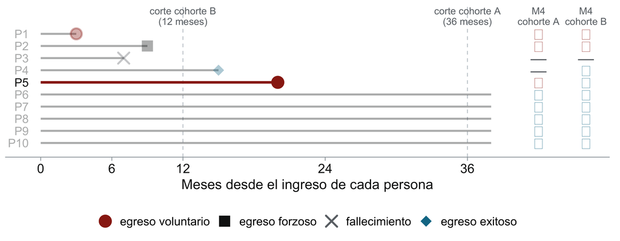

La cohorte A entró hace 36 meses y la B hace 12. M4 dice 63% y 78%. Toda la diferencia es P5, que ya se fue en A y todavía no en B.

## Con M5, graduarse no es fracaso, pero la fecha sigue mandando

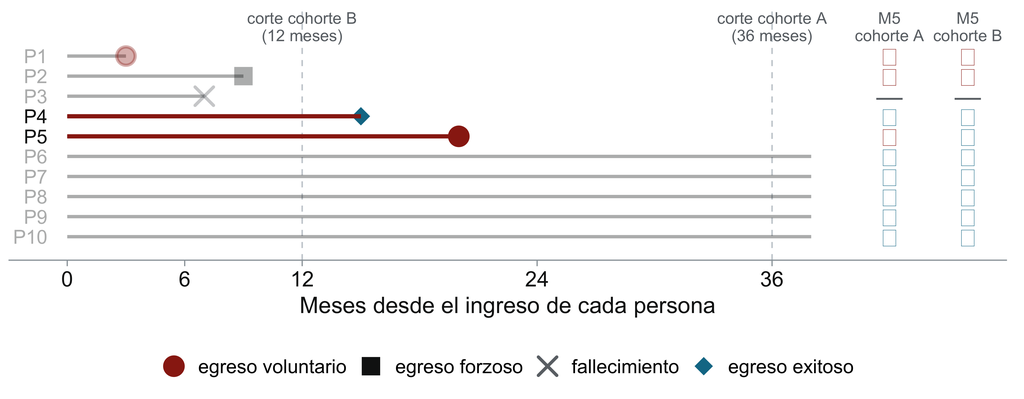

M5 cuenta a P4, que se gradúa, como éxito en las dos cohortes. Aun así da 67% en A y 78% en B: 5 y 7 puntos en el concurso. Otra vez la diferencia es solo P5, que en A ya se fue y en B todavía no.

## Las mismas personas con M6: 90% o 0% según el mes de ingreso

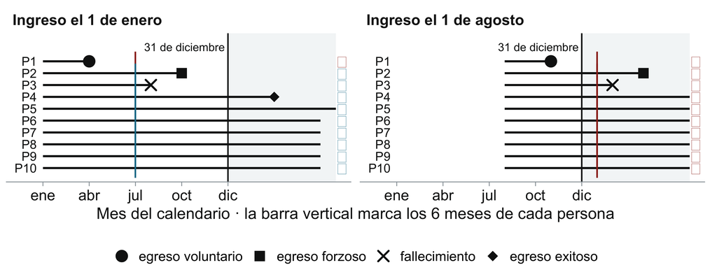

En enero, 9 de 10 cumplen 6 meses antes del 31 de diciembre, incluida P3, que fallece en el mes 7. En agosto, nadie alcanza.

# La propuesta

Retención por cohorte a horizonte fijo, con el reloj de cada persona

## M7 da 79% para las dos cohortes. Es M4 con reloj

$$\hat S_c(h)=\prod_{j:\ \tau_j\le h}\left(1-\frac{d_j}{n_j}\right)
\qquad
E=\{V,F,X,R\}\ \text{evento},\quad \{A,G,H,M\}\ \text{censura}$$

| Mes | Qué pasa | En riesgo | $\hat S$ |
| --- | --- | --- | --- |
| 3 | Sale P1 ($V$) | 10 → 9 | 9/10 = **90%** = vinculación |
| 7 | Fallece P3 ($M$): no es fracaso, deja de estar en riesgo | 9 → 8 | 90% |
| 9 | Sale P2 ($F$) | 8 → 7 | 90% × 7/8 = **79%** |
| 12 | Horizonte · sostenimiento $\hat S(12)/\hat S(6)$ |  | 88% |

Misma definición de pérdida que M4, con un reloj por persona. $\hat S$ es la probabilidad de no haber tenido un egreso evitable, no la proporción que sigue en el programa. Un traslado por cierre del ejecutor no es egreso: la persona sigue alojada.

# Resultados

1.724 participantes, 15 ejecutores, 2019–2026. M7 frente a M4, M5 y M6

## Tres indicadores suben, la retención no

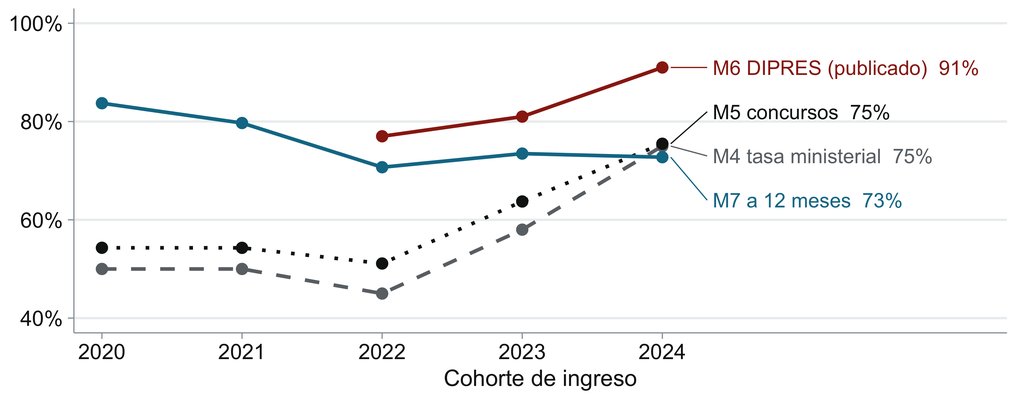

Entre las cohortes 2022 y 2024, M4 sube 30 puntos, M5 24 y M6 14. Con el reloj de cada persona, la retención a 12 meses pasa de 71% a 73%. Las tres cifras oficiales miden cuánto tiempo llevan las cohortes, no cuánto retienen.

## Con M7, Chile está en el rango internacional

| Organización | Desde | n | Ŝ(6) | Ŝ(12)/Ŝ(6) | Ŝ(12) | Ŝ(24) |
| --- | --- | --- | --- | --- | --- | --- |
| A | 2019 | 288 | 91% | 95% | 86% | 78% |
| J | 2024 | 52 | 86% | 97% | 84% | 67% |
| C | 2020 | 265 | 90% | 89% | 81% | 69% |
| G | 2019 | 105 | 89% | 89% | 80% | 68% |
| K | 2022 | 47 | 86% | 90% | 78% | 66% |
| E | 2020 | 139 | 83% | 90% | 75% | 64% |
| I | 2021 | 70 | 85% | 88% | 75% | 66% |
| B | 2020 | 244 | 83% | 87% | 73% | 57% |
| D | 2020 | 163 | 87% | 83% | 72% | 58% |
| F | 2021 | 116 | 83% | 85% | 71% | 65% |
| N | 2024 | 36 | 92% | 77% | 70% | 57% |
| L | 2022 | 47 | 72% | 81% | 59% | 53% |
| H | 2022 | 87 | 71% | 81% | 58% | 47% |
| M | 2025 | 42 | 75% | — | — | — |
| O | 2025 | 23 | 91% | — | — | — |

## M7 frente a M4: la tasa sube, la retención no se mueve

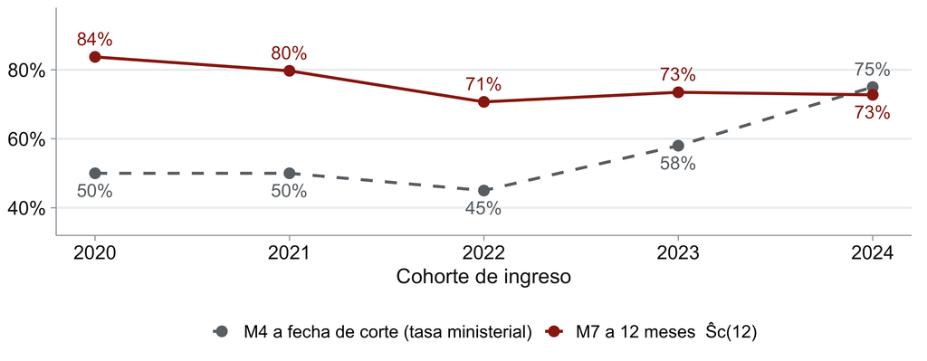

M4 sube de 45% a 75% entre las cohortes 2022 y 2024 porque la de 2024 llevaba 10 meses expuesta y la de 2022, 35. Es la P5 del ejemplo, multiplicada por cientos. A 12 meses, las dos retienen lo mismo: 71% y 73%.

## M7 frente a M6: DIPRES publica 91% con un techo de 55%

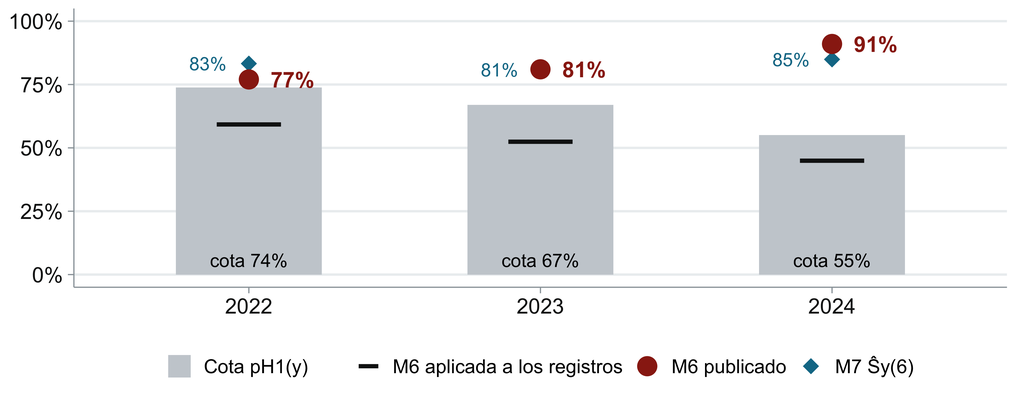

Quien ingresa después de junio no suma 6 meses en el año, así que $I(y)\le p_{H1}(y)$. En 2024 el techo era 55% y la fórmula literal da 45%, pero DIPRES publicó 91%. La retención a 6 meses fue 83%, 81% y 85%: el indicador subió 14 puntos y la retención no se movió.

## M7 frente a M5: la antigüedad se paga como mal desempeño

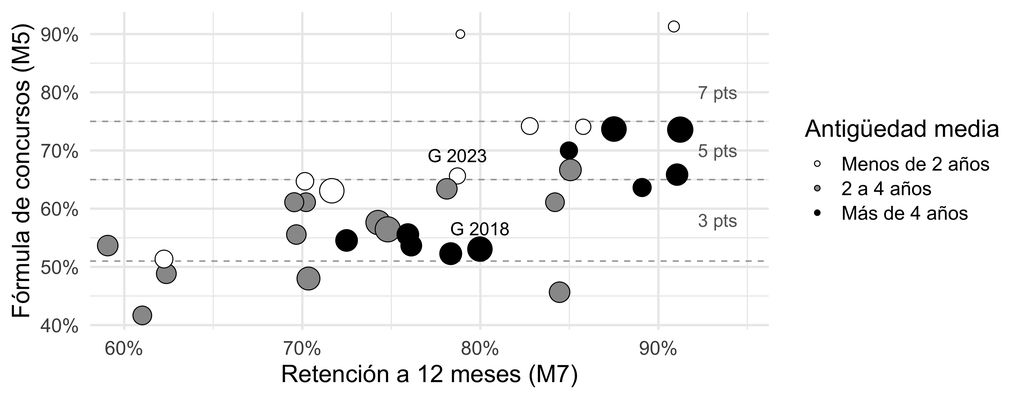

31 convenios. A igual $\hat S(12)$, cada año de antigüedad resta 6 puntos de M5 (IC 4–8), y pasa lo mismo dentro de cada organización. Mismo ejecutor y región, 80% y 79% a 12 meses: 3 y 5 puntos.

# Riesgos y cierre

Qué incentiva un indicador sin tiempo cuando decide convenios

## Tres omisiones, una estructura de incentivos

1. **El tiempo.** Una tasa a fecha de corte premia la antigüedad de la cartera y castiga la rotación. Graduar a alguien abre un cupo para una persona nueva, que entra al período de mayor riesgo.
2. **La definición de fracaso.** Todo egreso voluntario cuenta como pérdida, aunque una parte sean salidas a una vivienda propia o con la familia. Decidir irse se registra como fracaso del programa.
3. **La falta de ajuste.** No se registra la ruta de entrada ni la complejidad de las personas. La entrada desde redes propias rinde más que la entrada fría desde la calle, y el indicador lo trata como desempeño.

En un sistema de cupos fijos y convenios concursados, cada omisión es un incentivo: retener a toda costa, recodificar y seleccionar. Son riesgos que el diseño crea, no conductas que hayamos observado.

## Qué cambiar

- **Chile.** El MDSF se comprometió a rediseñar sus indicadores en el Sistema Calle. La prueba es simple: si el nuevo no es invariante a la exposición, volverá a medir la expansión y a llamarla resultado. La fórmula de los concursos también.
- **La métrica.** Retención por cohorte a 6 y 12 meses, con el reloj desde la entrada a la vivienda, graduación y mortalidad aparte y la misma definición para todos. Dialoga con el horizonte que DIPRES ya usa.
- **El registro.** Anotar el destino al egreso y la ruta de entrada. Sin eso no se puede distinguir un fracaso de una salida a vivienda, ni comparar ejecutores con justicia.
- **La región.** En programas jóvenes y en expansión, las métricas a fecha de corte son las que más halagan y más engañan.

Una cifra de retención que mejora solo porque el programa crece **no mide retención**.

# Respaldo

## Cohortes anuales con M7

| Cohorte | $n$ | $\hat S(6)$ | $\hat S(12)/\hat S(6)$ | $\hat S(12)$ | En riesgo a 12 m |
| --- | --- | --- | --- | --- | --- |
| 2019–20 | 190 | 89% | 94% | 83% | 142 |
| 2021 | 258 | 89% | 89% | 80% | 191 |
| 2022 | 260 | 83% | 85% | 71% | 172 |
| 2023 | 206 | 81% | 91% | 73% | 139 |
| 2024 | 356 | 85% | 86% | 73% | 219 |
| 2025 | 290 | 86% | 87% | 74% | 101 |

Los traslados por el cierre de un ejecutor en 2025 se tratan como continuidad.

## M6 frente a lecturas alternativas

| Lectura | 2022 | 2023 | 2024 |
| --- | --- | --- | --- |
| Publicado (DIPRES) | 77% | 81% | 91% |
| Techo $p_{H1}(y)$ | 74% | 67% | 55% |
| Fórmula literal sobre registros | 59% | 52% | 45% |
| Solo ingresos del primer semestre | 82% | 82% | 85% |
| Retención a 6 meses (M7) | 83% | 81% | 85% |

## Ejecutores

| Organización A frente al resto | HR | IC 95% |
| --- | --- | --- |
| Egreso evitable | **0,52** | 0,40–0,67 |
| Voluntario | 0,41 | 0,27–0,62 |
| Forzoso | 0,65 | 0,46–0,91 |

Cox por causa específica ajustado por sexo, n = 1.724, 591 eventos. Un modelo de fragilidad por organización encuentra diferencias entre ejecutores (LR 41,6; p < 0,001) que desaparecen al excluir A y H. Organización B queda octava de trece en M5 y en M7.

## Lo que el análisis no puede afirmar

- **Riesgos competitivos.** Censurar $G$, $H$ y $M$ supone independencia; con una población envejecida es optimista. A 4 años solo 37% sigue en el programa.
- **Sin covariables.** Solo sexo. $C=0{,}54$ por diseño del registro.
- **El evento lo codifica el ejecutor.** Los mismos incentivos contaminan $E$.
- **El techo identifica la incompatibilidad, no el mecanismo.** No sabemos cómo se calculó el 91%.
- **Convenciones.** Los traslados por cierre cuentan como continuidad: $\hat S(12)$ = 76%. Si todo traslado fuera egreso, bajaría a 73%.